# True coding regions that fail the coding test, and two fallbacks

This notebook supports the Results section “True coding regions that fail the coding test, and two fallbacks”, including its paragraph “Homology evidence recovers true coding regions, mostly in fragments” (`../manuscript/sections/results_coding_failures.tex`), and draws Fig. 5 (`fig:failures`, `figures/fig5_failures.{pdf,png}`). Provenance: E12 (the coding-failure analysis), E07 (homology runs of the benchmark) and E25 (final release runs).

**Release rule.** The analysis of E12 used the development rule: $S_1>0$, frame contrast $C=S_1-\max(S_2,S_3)>0$ and, below 300 nt, a fixed short-ORF test ($C \ge 200\mu$). The text now quotes the release analysis. Here the analysis is rerun on the release predictions (`pytd_v7`: PyTD 3a793ff, release defaults; Perl gives identical predictions, E25), with the release coding test: $S_1>0$, $C>0$ and target-decoy q-value $\le 0.05$. The q-value of each candidate is read from the run’s `decoy_qvalues.tsv`.

Data (`data/long_orf_failures/v7/`, written by `pipeline/derive/05_long_orf_failures_v7.sh`, which runs `05_long_orf_failures_v7.py`, `05_summarize_v7.py`, `05_length_vs_homology_v7.py` and `05_fig5_tables_v7.py`; these are copies of `analyses/long_orf_failures/*.py` changed for the release rule):

- the matched CDS tables of the 8 benchmark organisms (complete transcripts, UTRs trimmed to 250 nt), aggregated: by organism, length, GC3 quintile, chromosome, failure cause, and model;
- homology flags from the release homology runs (`pytd_v7_homology`), which search all LongOrfs ORFs ($\ge$ 50 aa) against Swiss-Prot (minus the organism’s own entries) and Pfam. E12 used older runs with a 100-aa minimum, so CDSs of 50–99 aa now have homology flags;
- the truth-trained Markov models of E12 (two folds by gene) now pass an ORF only if it also has a q-value $\le 0.05$ computed from decoys scored with the same model. The decoys are regenerated as PyTD generates them; with the run’s own model this reproduces every q-value in `decoy_qvalues.tsv` (checked below);
- the homology comparison (Fig. 5d,e) uses `data/benchmark/homology_v7h_vs_abinitio.tsv`: the released homology mode (PyTD a5b24c3, homology-assisted start refinement; runs `pytd_v7h_homology`) minus the ab initio release runs (`pytd_v7`), from `benchmark_v2/scripts/compare_homology.py` on `data/benchmark/final_v7/v7h_homology_scores.tsv` (`pipeline/derive/05_homology_v7h_table.sh`; E25 addendum of 2026-10-28, E33). Selection and stops equal the earlier 3a793ff homology runs (`pytd_v7_homology`, `homology_vs_abinitio.tsv`, kept and compared below); only start codons differ. The development comparison (`pytd_dev_v2_homology` minus `pytd_dev_v2`) is kept as `homology_vs_abinitio.dev_v2.tsv`.

```r
V7 <- function(f) read_tab("long_orf_failures", "v7", f)
by_org <- V7("summary_by_org.tsv")
by_len <- V7("summary_by_length.tsv")
oracle <- V7("oracle_models.tsv")
flags <- V7("explanation_flags.tsv")
rate_feat <- V7("fail_rate_by_feature.tsv")
by_chr <- V7("fail_by_chromosome.tsv") %>% mutate(seqid = as.character(seqid))
rp <- V7("ribosomal_proteins.tsv")
feat <- V7("features_fail_vs_pass.tsv")
fam <- V7("family_keyword_enrichment.tsv")
utr <- V7("utr_effect.tsv")
meta <- V7("org_meta.tsv")
lvh <- V7("length_vs_homology_fallback.tsv")
lro <- V7("length_rule_only_predictions.tsv") %>%
  separate(dataset, c("src", "org", "input"), sep = ":", remove = FALSE)
alt <- V7("alt_rules_negatives.tsv")
dmel_c <- V7("dmel_gc3_rescue.tsv")
long_fail <- V7("failing_ge1kb.tsv")
reasons <- V7("reasons_by_length.tsv")
hom <- read_tab("benchmark", "homology_v7h_vs_abinitio.tsv")
hom_3a7 <- read_tab("benchmark", "homology_vs_abinitio.tsv")  # 3a793ff homology runs (no start assist)
# development-rule tables of E12, for comparison
dev_by_org <- read_tab("long_orf_failures", "summary_by_org.tsv")
dev_by_len <- read_tab("long_orf_failures", "summary_by_length.tsv")

ALL <- by_org %>% filter(org == "ALL")
LEN_BINS <- c("0-299", "300-599", "600-999", "1000-1999", "2000-4999", ">=5000")
```

## Release runs and reproduction checks

```r
repro <- meta %>% transmute(org, run, homology_source, L_star, n_truth, n_training, training_is_truth_cds,
                            q_values = check_td_q_n, q_identical = check_td_q_identical,
                            score_diffs = check_td_scores_ndiff_gt0.011, decoy_orfs = n_decoy_orfs,
                            shuffles = n_decoy_shuffles)
kable(repro)
```

| org | run | homology_source | L_star | n_truth | n_training | training_is_truth_cds | q_values | q_identical | score_diffs | decoy_orfs | shuffles |
| --- | --- | --- | --- | --- | --- | --- | --- | --- | --- | --- | --- |
| athal | pytd_v7 | pytd_v7_homology | 663 | 26867 | 500 | 500 | 56093 | 56093 | 0 | 38282 | 1 |
| creinhardtii | pytd_v7 | pytd_v7_homology | 1347 | 17621 | 500 | 500 | 70762 | 70762 | 0 | 136000 | 1 |
| dmel | pytd_v7 | pytd_v7_homology | 804 | 13884 | 500 | 499 | 38900 | 38900 | 0 | 49992 | 1 |
| human | pytd_v7 | pytd_v7_homology | 804 | 19167 | 500 | 499 | 63551 | 63551 | 0 | 69070 | 1 |
| mouse | pytd_v7 | pytd_v7_homology | 804 | 21409 | 500 | 500 | 67875 | 67875 | 0 | 71458 | 1 |
| pfalciparum | pytd_v7 | pytd_v7_homology | 519 | 5281 | 500 | 500 | 10071 | 10071 | 0 | 3865 | 2 |
| spombe | pytd_v7 | pytd_v7_homology | 615 | 5100 | 500 | 500 | 10090 | 10090 | 0 | 19091 | 3 |
| tthermophila | pytd_v7 | pytd_v7_homology | Inf | 26456 | 500 | 499 | 158647 | 158647 | 0 | 225350 | 1 |

```r
stopifnot(all(repro$q_identical == repro$q_values), all(repro$score_diffs == 0))
```

For every organism, the Markov scores recomputed here equal `longest_orfs.cds.scores`, and the q-values recomputed from the regenerated decoys equal `decoy_qvalues.tsv` for all 475,989 LongOrfs candidates. The same code therefore gives valid q-values for the truth-trained models below.

## How often

```r
fail_pct <- ALL$fail_coding_pct
len_all <- by_len %>% filter(org == "ALL") %>% mutate(cds_len_bin = factor(cds_len_bin, LEN_BINS)) %>% arrange(cds_len_bin)
lp <- setNames(len_all$fail_coding_pct, as.character(len_all$cds_len_bin))
reason_short <- len_all %>% filter(cds_len_bin == "0-299")
n_ge1kb <- nrow(long_fail)
named <- c("Muc14A", "kl-2", "kl-3", "MUC4", "FLG", "HRNR", "COL4A4", "ELN")
named_tab <- long_fail %>% filter(gene_name %in% named) %>%
  group_by(org, gene_name) %>% slice_max(cds_len, n = 1, with_ties = FALSE) %>% ungroup() %>%
  select(org, gene_name, cds_len, fail_reason, category, decoy_q)
dev_all <- dev_by_org %>% filter(org == "ALL")
```

Of 135,429 annotated CDSs matched to a LongOrfs candidate (135,785 truth CDSs; E12 matched 135,429), **4.9%** fail the release coding test (development rule: 4.9%). By cause: $S_1 \le 0$ 3,091, shifted frame $\ge S_1$ 1,189, q-value above 0.05 2,408. E12 E25

The failure rate by annotated CDS length (all organisms):

```r
cmp_len <- len_all %>% select(cds_len_bin, n, fail_coding, fail_coding_pct, fail_S1_le0, fail_shifted_frame,
                              fail_decoy_q, rescued_by_long_rule, still_lost, still_lost_pct) %>%
  left_join(dev_by_len %>% filter(org == "ALL") %>% select(cds_len_bin, dev_n = n, dev_fail_pct = fail_coding_pct),
            by = "cds_len_bin")
kable(cmp_len, caption = "All organisms, release rule; dev_*: development rule (E12).")
```

All organisms, release rule; dev_*: development rule (E12).

| cds_len_bin | n | fail_coding | fail_coding_pct | fail_S1_le0 | fail_shifted_frame | fail_decoy_q | rescued_by_long_rule | still_lost | still_lost_pct | dev_n | dev_fail_pct |
| --- | --- | --- | --- | --- | --- | --- | --- | --- | --- | --- | --- |
| 0-299 | 5713 | 3026 | 52.97 | 1102 | 381 | 1543 | 0 | 3026 | 52.97 | 5713 | 67.04 |
| 300-599 | 18775 | 2540 | 13.53 | 1285 | 471 | 784 | 4 | 2536 | 13.51 | 18775 | 9.35 |
| 600-999 | 27683 | 724 | 2.62 | 490 | 153 | 81 | 126 | 598 | 2.16 | 27683 | 2.32 |
| 1000-1999 | 47175 | 283 | 0.60 | 141 | 142 | 0 | 208 | 75 | 0.16 | 47175 | 0.60 |
| 2000-4999 | 29736 | 89 | 0.30 | 59 | 30 | 0 | 84 | 5 | 0.02 | 29736 | 0.30 |
| >=5000 | 6347 | 26 | 0.41 | 14 | 12 | 0 | 25 | 1 | 0.02 | 6347 | 0.41 |

- below 300 nt: 53.0% (1,543 of 3,026 failures through the q-value; development rule 67%, mostly the fixed short-ORF test);
- 300–599 nt: 13.5%; 600–999 nt: 2.6%;
- 1–2 kb: 0.6%; 2–5 kb: 0.3%; $\ge$ 5 kb: 0.4%.

Failing CDSs of at least 1 kb: **398**. The named genes of the text:

```r
kable(named_tab)
```

| org | gene_name | cds_len | fail_reason | category | decoy_q |
| --- | --- | --- | --- | --- | --- |
| dmel | Muc14A | 48672 | S1<=0 | fail_coding_long_rescued | NA |
| dmel | kl-2 | 13380 | S1<=0 | fail_coding_long_rescued | NA |
| dmel | kl-3 | 13782 | S1<=0 | fail_coding_long_rescued | NA |
| human | COL4A4 | 5073 | shifted_frame>=S1 | fail_coding_long_rescued | NA |
| human | ELN | 2175 | shifted_frame>=S1 | fail_coding_long_rescued | NA |
| human | FLG | 12186 | shifted_frame>=S1 | fail_coding_long_rescued | NA |
| human | HRNR | 8553 | shifted_frame>=S1 | fail_coding_long_rescued | NA |
| human | MUC4 | 16239 | shifted_frame>=S1 | fail_coding_long_rescued | NA |

```r
kable(long_fail %>% group_by(org) %>% slice_max(cds_len, n = 5, with_ties = FALSE) %>% ungroup() %>%
        select(org, gene_name, transcript_id, cds_len, fail_reason, category))
```

| org | gene_name | transcript_id | cds_len | fail_reason | category |
| --- | --- | --- | --- | --- | --- |
| athal | AT1G97767 | AT1G97767.1 | 2283 | S1<=0 | fail_coding_long_rescued |
| athal | AT5G51500 | AT5G51500.1 | 1623 | S1<=0 | fail_coding_long_rescued |
| athal | AT2G03000 | AT2G03000.1 | 1608 | shifted_frame>=S1 | fail_coding_long_rescued |
| athal | AT1G09750 | AT1G09750.1 | 1350 | S1<=0 | fail_coding_long_rescued |
| athal | AT5G35770 | AT5G35770.1 | 1341 | S1<=0 | fail_coding_long_rescued |
| creinhardtii | CHLRE_12g489300v5 | rna-XM_043067891.1 | 3192 | S1<=0 | fail_coding_long_rescued |
| creinhardtii | CHLRE_08g386100v5 | rna-XM_043065372.1 | 2298 | S1<=0 | fail_coding_long_rescued |
| creinhardtii | CHLRE_16g662702v5 | rna-XM_043071015.1 | 2109 | S1<=0 | fail_coding_long_rescued |
| creinhardtii | CHLRE_12g488351v5 | rna-XM_043067877.1 | 1815 | S1<=0 | fail_coding_long_rescued |
| creinhardtii | CHLRE_06g252750v5 | rna-XM_001696588.2 | 1794 | S1<=0 | fail_coding_long_rescued |
| dmel | Muc14A | FBtr0074205 | 48672 | S1<=0 | fail_coding_long_rescued |
| dmel | kl-3 | FBtr0346771 | 13782 | S1<=0 | fail_coding_long_rescued |
| dmel | kl-2 | FBtr0346722 | 13380 | S1<=0 | fail_coding_long_rescued |
| dmel | Nipped-A | FBtr0303293 | 11373 | S1<=0 | fail_coding_long_rescued |
| dmel | Muc12Ea | FBtr0475073 | 9966 | shifted_frame>=S1 | fail_coding_long_rescued |
| human | MUC4 | ENST00000463781.8 | 16239 | shifted_frame>=S1 | fail_coding_long_rescued |
| human | FLG | ENST00000368799.2 | 12186 | shifted_frame>=S1 | fail_coding_long_rescued |
| human | HRNR | ENST00000368801.4 | 8553 | shifted_frame>=S1 | fail_coding_long_rescued |
| human | FLG2 | ENST00000388718.5 | 7176 | shifted_frame>=S1 | fail_coding_long_rescued |
| human | COL4A4 | ENST00000396625.5 | 5073 | shifted_frame>=S1 | fail_coding_long_rescued |
| mouse | Muc19 | ENSMUST00000239545.2 | 22575 | shifted_frame>=S1 | fail_coding_long_rescued |
| mouse | Flg2 | ENSMUST00000194707.4 | 20127 | shifted_frame>=S1 | fail_coding_long_rescued |
| mouse | Hrnr | ENSMUST00000093774.4 | 10236 | shifted_frame>=S1 | fail_coding_long_rescued |
| mouse | Rptn | ENSMUST00000045912.3 | 3357 | shifted_frame>=S1 | fail_coding_long_rescued |
| mouse | Gm4924 | ENSMUST00000210381.3 | 2901 | shifted_frame>=S1 | fail_coding_long_rescued |
| tthermophila | TTHERM_00489480 | g22209.t1 | 5487 | shifted_frame>=S1 | fail_coding_lost |
| tthermophila | TTHERM_01098988 | g19363.t1 | 2748 | S1<=0 | fail_coding_lost |
| tthermophila | TTHERM_00417830 | g11971.t1 | 2361 | shifted_frame>=S1 | fail_coding_lost |
| tthermophila | TTHERM_00891260 | g14219.t1 | 2172 | S1<=0 | fail_coding_lost |
| tthermophila | TTHERM_00566849 | g29966.t1 | 2127 | shifted_frame>=S1 | fail_coding_lost |

### The length rule

```r
tt_len <- by_len %>% filter(org == "tthermophila", cds_len_bin %in% c("1000-1999", "2000-4999", ">=5000"))
tt_lost_1kb <- sum(tt_len$still_lost)
# failing CDSs with an ORF at or above L* that the rule does not keep (should be T. thermophila only)
above_lstar <- by_len %>% filter(org != "ALL") %>% group_by(org) %>%
  summarise(rescued = sum(rescued_by_long_rule), still_lost = sum(still_lost), .groups = "drop")
lvh_all <- lvh %>% filter(org == "ALL")
lo_pct <- 100 * lvh_all$length_only / lvh_all$rescued_by_length
kable(lvh, caption = "Failing true CDSs retained by the length rule, and whether they also have a homology hit.")
```

Failing true CDSs retained by the length rule, and whether they also have a homology hit.

| org | fail_coding | rescued_by_length | with_homology_data | also_homology_hit | length_only |
| --- | --- | --- | --- | --- | --- |
| athal | 1119 | 60 | 60 | 46 | 14 |
| creinhardtii | 782 | 8 | 8 | 3 | 5 |
| dmel | 613 | 183 | 183 | 143 | 40 |
| human | 505 | 42 | 42 | 40 | 2 |
| mouse | 708 | 150 | 150 | 129 | 21 |
| pfalciparum | 24 | 1 | 1 | 0 | 1 |
| spombe | 115 | 3 | 3 | 1 | 2 |
| tthermophila | 2822 | 0 | 0 | 0 | 0 |
| ALL | 6688 | 447 | 447 | 362 | 85 |

The length rule keeps every failing CDS whose ORF reaches $L^\ast$; it is off in *T. thermophila*, where 76 failing CDSs of at least 1 kb are lost. In total it retains **447** failing true CDSs; **85** (19.0%) of them have no Swiss-Prot or Pfam hit. E12

### Not predicted, and predictions kept by length alone

```r
lost_pct <- ALL$fail_lost_pct_of_matched
lro_b <- lro %>% filter(src == "bench_v3")
lro_cplt <- lro_b %>% filter(input == "complete")
lo_total <- sum(lro_cplt$length_rule_only)
lo_false <- sum(lro_cplt$length_rule_only - lro_cplt$lo_is_truth_cds)
h_lnc <- lro_b %>% filter(org == "human", input == "complete.wLnc")
kable(lro_b %>% select(org, input, L_star, predictions, length_rule_only, length_rule_only_pct, lo_is_truth_cds,
                       lo_on_negative_transcript, lo_other_orf_on_coding_transcript))
```

| org | input | L_star | predictions | length_rule_only | length_rule_only_pct | lo_is_truth_cds | lo_on_negative_transcript | lo_other_orf_on_coding_transcript |
| --- | --- | --- | --- | --- | --- | --- | --- | --- |
| athal | complete | 663 | 25745 | 58 | 0.225 | 57 | 0 | 1 |
| athal | complete.wRand | 663 | 25677 | 74 | 0.288 | 73 | 0 | 1 |
| creinhardtii | complete | 1347 | 16896 | 7 | 0.041 | 7 | 0 | 0 |
| creinhardtii | complete.wRand | 1347 | 16943 | 66 | 0.390 | 8 | 58 | 0 |
| dmel | complete | 804 | 13376 | 180 | 1.346 | 180 | 0 | 0 |
| dmel | complete.wRand | 804 | 13384 | 189 | 1.412 | 182 | 7 | 0 |
| human | complete | 804 | 18712 | 45 | 0.240 | 41 | 0 | 4 |
| human | complete.wLnc | 726 | 20148 | 214 | 1.062 | 49 | 159 | 6 |
| human | complete.wRand | 804 | 18829 | 127 | 0.674 | 40 | 83 | 4 |
| mouse | complete | 804 | 20846 | 115 | 0.552 | 115 | 0 | 0 |
| mouse | complete.wLnc | 726 | 22274 | 181 | 0.813 | 115 | 66 | 0 |
| mouse | complete.wRand | 804 | 20883 | 138 | 0.661 | 112 | 26 | 0 |
| pfalciparum | complete | 519 | 5255 | 1 | 0.019 | 1 | 0 | 0 |
| pfalciparum | complete.wRand | 519 | 5265 | 3 | 0.057 | 3 | 0 | 0 |
| spombe | complete | 615 | 4969 | 3 | 0.060 | 3 | 0 | 0 |
| spombe | complete.wRand | 615 | 4983 | 3 | 0.060 | 3 | 0 | 0 |
| tthermophila | complete | Inf | 23979 | 0 | 0.000 | 0 | 0 | 0 |
| tthermophila | complete.wRand | Inf | 23939 | 0 | 0.000 | 0 | 0 | 0 |

**4.6%** of matched true CDSs fail the coding test and are not retained by the length rule. Predictions kept by length alone are 0.0–1.4% of all predictions. On complete transcripts 5 of 409 are not the annotated CDS; on human lncRNA negatives 49 are true and 159 are on lncRNAs. E12

## Why

### Exclusive attribution (failures of at least 300 nt)

```r
attr_lab <- c(atypical_gc3_composition = "atypical GC3", low_complexity_or_repetitive = "low complexity / repetitive",
              no_homology_orphan = "no homology", stronger_out_of_frame_orf = "stronger ORF in another frame",
              unexplained = "unexplained")
attr <- flags %>% filter(startsWith(flag, "attr:")) %>% mutate(cause = sub("attr:", "", flag))
attr_all <- attr %>% filter(org == "ALL") %>% { setNames(.$fail_pct, .$cause) }
kable(attr %>% select(org, cause, n_fail, fail_pct) %>% pivot_wider(names_from = cause, values_from = fail_pct))
```

| org | n_fail | low_complexity_or_repetitive | atypical_gc3_composition | stronger_out_of_frame_orf | no_homology_orphan | unexplained |
| --- | --- | --- | --- | --- | --- | --- |
| athal | 380 | 22.63 | 57.11 | 1.05 | 10.53 | 8.68 |
| creinhardtii | 350 | 11.71 | 63.71 | 1.14 | 21.43 | 2.00 |
| dmel | 380 | 16.05 | 79.74 | 0.53 | 2.11 | 1.58 |
| human | 291 | 55.67 | 21.99 | 0.34 | 3.09 | 18.90 |
| mouse | 486 | 63.99 | 16.05 | 0.62 | 4.94 | 14.40 |
| pfalciparum | 6 | 0.00 | 100.00 | 0.00 | 0.00 | 0.00 |
| spombe | 50 | 44.00 | 18.00 | 0.00 | 28.00 | 10.00 |
| tthermophila | 2246 | 24.35 | 18.57 | 9.35 | 46.48 | 1.25 |
| ALL | 4189 | 29.36 | 31.44 | 5.35 | 28.98 | 4.87 |

Of 4,189 failures of at least 300 nt: atypical GC3 31.4%, low complexity 29.4%, no homology 29.0%, stronger ORF in another frame 5.3% (the last two together 34.3%), unexplained 4.9%. E12

### Codon-usage heterogeneity

```r
dq <- rate_feat %>% filter(org == "dmel", feature == "gc3") %>% arrange(quintile)
chr4 <- by_chr %>% filter(org == "dmel", seqid == "4")
chrY <- by_chr %>% filter(org == "dmel", seqid == "Y")
tt_rp <- rp %>% filter(org == "tthermophila")
o_all <- oracle %>% filter(org == "ALL")
o_dmel <- oracle %>% filter(org == "dmel")
other_models <- c(o_all$all_fail_ge300_pct, o_all$rand500_fail_ge300_pct, o_all$long500_fail_ge300_pct)
purity <- meta$training_is_truth_cds / meta$n_training
kable(dq %>% select(quintile, lo, hi, n, fail_score, fail_score_pct), caption = "D. melanogaster, ORFs >= 300 nt, by GC3 quintile.")
```

D. melanogaster, ORFs >= 300 nt, by GC3 quintile.

| quintile | lo | hi | n | fail_score | fail_score_pct |
| --- | --- | --- | --- | --- | --- |
| 1 | 0.2113 | 0.5611 | 2635 | 366 | 13.89 |
| 2 | 0.5613 | 0.6280 | 2634 | 9 | 0.34 |
| 3 | 0.6280 | 0.6761 | 2635 | 3 | 0.11 |
| 4 | 0.6761 | 0.7288 | 2634 | 1 | 0.04 |
| 5 | 0.7289 | 0.9564 | 2634 | 1 | 0.04 |

```r
kable(oracle %>% select(org, n, td_fail_pct, td_fail_ge300_pct, all_fail_ge300_pct, rand500_fail_ge300_pct,
                        long500_fail_ge300_pct, gc3match500_fail_ge300_pct, td_scorefail_n,
                        gc3match500_rescues_td_scorefail_pct),
      caption = "Failure rates (%) under TransDecoder's model (td) and truth-trained models; rescue by the GC3-matched model.")
```

Failure rates (%) under TransDecoder’s model (td) and truth-trained models; rescue by the GC3-matched model.

| org | n | td_fail_pct | td_fail_ge300_pct | all_fail_ge300_pct | rand500_fail_ge300_pct | long500_fail_ge300_pct | gc3match500_fail_ge300_pct | td_scorefail_n | gc3match500_rescues_td_scorefail_pct |
| --- | --- | --- | --- | --- | --- | --- | --- | --- | --- |
| athal | 26772 | 4.18 | 1.49 | 0.75 | 1.04 | 1.48 | 0.87 | 1119 | 37.18 |
| creinhardtii | 17621 | 4.44 | 2.09 | 1.70 | 1.91 | 2.22 | 1.42 | 782 | 20.84 |
| dmel | 13784 | 4.45 | 2.88 | 2.50 | 4.25 | 2.97 | 0.47 | 613 | 63.30 |
| human | 19144 | 2.64 | 1.55 | 1.42 | 1.66 | 1.60 | 1.05 | 505 | 35.64 |
| mouse | 21361 | 3.31 | 2.32 | 1.81 | 2.13 | 2.36 | 1.46 | 708 | 45.62 |
| pfalciparum | 5277 | 0.45 | 0.12 | 0.02 | 0.04 | 0.14 | 0.06 | 24 | 37.50 |
| spombe | 5081 | 2.26 | 1.02 | 0.90 | 1.21 | 0.98 | 1.78 | 115 | 20.87 |
| tthermophila | 26389 | 10.69 | 8.73 | 8.33 | 8.59 | 8.68 | 8.53 | 2822 | 9.74 |
| ALL | 135429 | 4.94 | 3.20 | 2.78 | 3.19 | 3.23 | 2.53 | 6688 | 26.58 |

- *D. melanogaster*: 13.9% of CDSs ($\ge$ 300 nt) in the lowest GC3 quintile fail, against 0.0–0.3% in the others; chromosome 4 40 of 80, chromosome Y 8 of 22.
- *T. thermophila* ribosomal proteins: 29 of 60 fail.
- GC3-matched model: rescues 26.6% of failures overall and 63.3% in *D. melanogaster*; 39 of the 40 on chromosome 4.
- Models trained on all annotated CDSs, 500 random or the 500 longest: 2.8–3.2% of ORFs $\ge$ 300 nt fail, against 3.2% with TransDecoder’s model. TransDecoder’s training ORFs are 99.8–100.0% annotated CDSs.

E12

### Low-complexity and repetitive proteins

```r
hm <- flags %>% filter(org %in% c("human", "mouse"), flag == "f_low_complexity")
lowc_fail <- sum(hm$n_fail * hm$fail_pct) / sum(hm$n_fail)
lowc_ctrl <- sum(hm$n_ctrl * hm$ctrl_pct) / sum(hm$n_ctrl)
hm_shift <- by_org %>% filter(org %in% c("human", "mouse")) %>% select(org, fail_coding, fail_S1_le0, fail_shifted_frame, fail_decoy_q)
krtap <- fam %>% filter(org == "human", kind == "name_prefix", term == "KRTAP")
fh <- feat %>% filter(org == "human", feature %in% c("aa_C", "aa_S", "aa_G", "aa_P", "seg_lowc_frac")) %>%
  select(feature, n_fail, n_ctrl, fail_mean, ctrl_mean, mannwhitney_p)
cys <- fh %>% filter(feature == "aa_C")
seg <- fh %>% filter(feature == "seg_lowc_frac")
kable(hm_shift, caption = "Human and mouse failures by cause (all lengths).")
```

Human and mouse failures by cause (all lengths).

| org | fail_coding | fail_S1_le0 | fail_shifted_frame | fail_decoy_q |
| --- | --- | --- | --- | --- |
| human | 505 | 35 | 176 | 294 |
| mouse | 708 | 54 | 359 | 295 |

```r
kable(fh, digits = 4, caption = "Human, failing ORFs >= 300 nt vs length-matched passing controls.")
```

Human, failing ORFs >= 300 nt vs length-matched passing controls.

| feature | n_fail | n_ctrl | fail_mean | ctrl_mean | mannwhitney_p |
| --- | --- | --- | --- | --- | --- |
| seg_lowc_frac | 291 | 1238 | 0.3235 | 0.1136 | 0 |
| aa_S | 291 | 1238 | 0.1050 | 0.0709 | 0 |
| aa_G | 291 | 1238 | 0.0948 | 0.0675 | 0 |
| aa_P | 291 | 1238 | 0.0833 | 0.0576 | 0 |
| aa_C | 291 | 1238 | 0.0986 | 0.0236 | 0 |

- 60.9% of human and mouse failures ($\ge$ 300 nt) are low-complexity or repetitive, against 13.8% of length-matched passing CDSs.
- Human *KRTAP*: 55 of 72 fail.
- Failing human CDSs: Cys 9.9% vs 2.4%; low-complexity fraction 0.324 vs 0.114 (2.8-fold).

E12

### Unconserved gene models

```r
tt_orph <- flags %>% filter(org == "tthermophila", flag == "f_orphan")
tt_alt <- flags %>% filter(org == "tthermophila", flag == "f_altframe_orf_stronger")
sp <- rate_feat %>% filter(feature == "has_sprot") %>% select(org, has_sprot = quintile, n, fail_score, fail_score_pct)
h_sp <- sp %>% filter(org == "human")
kable(sp %>% pivot_wider(names_from = has_sprot, values_from = c(n, fail_score, fail_score_pct)),
      caption = "Failure rate (ORFs >= 300 nt) by Swiss-Prot hit (0: none, 1: hit).")
```

Failure rate (ORFs >= 300 nt) by Swiss-Prot hit (0: none, 1: hit).

| org | n_0 | n_1 | fail_score_0 | fail_score_1 | fail_score_pct_0 | fail_score_pct_1 |
| --- | --- | --- | --- | --- | --- | --- |
| athal | 10159 | 15371 | 272 | 108 | 2.68 | 0.70 |
| creinhardtii | 9802 | 6918 | 334 | 16 | 3.41 | 0.23 |
| dmel | 4729 | 8443 | 239 | 141 | 5.05 | 1.67 |
| human | 591 | 18166 | 121 | 170 | 20.47 | 0.94 |
| mouse | 776 | 20159 | 171 | 315 | 22.04 | 1.56 |
| pfalciparum | 3037 | 2078 | 4 | 2 | 0.13 | 0.10 |
| spombe | 1339 | 3544 | 47 | 3 | 3.51 | 0.08 |
| tthermophila | 18881 | 6849 | 2182 | 64 | 11.56 | 0.93 |

- *T. thermophila*: 94.9% of failures have no Swiss-Prot or Pfam hit, against 52.2% of controls; 19.5% have a stronger ORF in another frame.
- Human: 20.5% of CDSs without a Swiss-Prot hit fail, against 0.9% with one.

E12

### UTR length

```r
kable(utr %>% select(org, n_trim, n_full, fail_pct_trim, fail_pct_full, predicted_pct_trim, predicted_pct_full,
                     category_changed, lost_only_in_full, lost_only_in_full_outcompeted))
```

| org | n_trim | n_full | fail_pct_trim | fail_pct_full | predicted_pct_trim | predicted_pct_full | category_changed | lost_only_in_full | lost_only_in_full_outcompeted |
| --- | --- | --- | --- | --- | --- | --- | --- | --- | --- |
| athal | 26772 | 26772 | 4.18 | 4.85 | 95.98 | 95.13 | 240 | 249 | 44 |
| creinhardtii | 17621 | 17621 | 4.44 | 5.35 | 95.44 | 94.47 | 217 | 211 | 27 |
| dmel | 13784 | 13784 | 4.45 | 5.87 | 96.71 | 94.98 | 222 | 260 | 140 |
| human | 19144 | 19144 | 2.64 | 3.65 | 97.53 | 96.44 | 287 | 256 | 31 |
| mouse | 21361 | 21361 | 3.31 | 4.66 | 97.21 | 95.73 | 396 | 364 | 36 |
| pfalciparum | 5277 | 5277 | 0.45 | 0.83 | 99.51 | 98.92 | 26 | 36 | 13 |
| spombe | 5081 | 5081 | 2.26 | 2.99 | 97.80 | 96.85 | 54 | 56 | 11 |
| tthermophila | 26389 | 26384 | 10.69 | 11.23 | 89.21 | 88.47 | 312 | 282 | 61 |

## Implications

```r
alt_r <- alt %>% filter(input == "complete.wRand") %>%
  mutate(pos_gain_pct = 100 * (pos_pass_A_no_S1 - pos_pass_current) / n_pos,
         neg_fold = neg_with_candidate_A_no_S1 / neg_with_candidate_current)
kable(alt %>% select(org, input, n_pos, n_neg, pos_pass_current, pos_pass_A_no_S1, neg_with_candidate_current,
                     neg_with_candidate_A_no_S1, check_q_identical, check_q_n))
```

| org | input | n_pos | n_neg | pos_pass_current | pos_pass_A_no_S1 | neg_with_candidate_current | neg_with_candidate_A_no_S1 | check_q_identical | check_q_n |
| --- | --- | --- | --- | --- | --- | --- | --- | --- | --- |
| athal | complete.wRand | 26867 | 26867 | 25608 | 25451 | 39 | 96 | 86727 | 86727 |
| creinhardtii | complete.wRand | 17621 | 17621 | 16833 | 16842 | 65 | 228 | 176904 | 176904 |
| dmel | complete.wRand | 13884 | 13884 | 13318 | 13408 | 44 | 116 | 73139 | 73139 |
| human | complete.wLnc | 19167 | 33668 | 18496 | 18488 | 1639 | 1613 | 136681 | 136681 |
| human | complete.wRand | 19167 | 19167 | 18686 | 18590 | 113 | 244 | 120309 | 120309 |
| mouse | complete.wLnc | 21409 | 31467 | 20608 | 20612 | 1640 | 1607 | 127401 | 127401 |
| mouse | complete.wRand | 21409 | 21409 | 20799 | 20747 | 42 | 167 | 127794 | 127794 |
| pfalciparum | complete.wRand | 5281 | 5281 | 5251 | 5255 | 13 | 28 | 12144 | 12144 |
| spombe | complete.wRand | 5100 | 5100 | 4958 | 4948 | 25 | 35 | 14724 | 14724 |
| tthermophila | complete.wRand | 26456 | 26456 | 23487 | 23313 | 49 | 385 | 402476 | 402476 |

```r
kable(alt_r %>% select(org, pos_gain_pct, neg_fold), digits = 2)
```

| org | pos_gain_pct | neg_fold |
| --- | --- | --- |
| athal | -0.58 | 2.46 |
| creinhardtii | 0.05 | 3.51 |
| dmel | 0.65 | 2.64 |
| human | -0.50 | 2.16 |
| mouse | -0.24 | 3.98 |
| pfalciparum | 0.08 | 2.15 |
| spombe | -0.20 | 1.40 |
| tthermophila | -0.66 | 7.86 |

Dropping $S_1>0$ (keeping $C>0$ and the q-value, recomputed with $C>0$ as the only eligibility condition) adds -0.66–0.6% of true CDSs as candidates, while the number of random sequences with a candidate changes 1.4- to 7.9-fold (median 2.5). Candidate counts are upper bounds on calls (one ORF per transcript is kept). E12

## Homology evidence recovers true coding regions, mostly in fragments

Release runs (`pytd_v7` vs `pytd_v7h_homology`, PyTD a5b24c3 with the homology-assisted start refinement; `data/benchmark/homology_v7h_vs_abinitio.tsv`). E25 E33

```r
hom <- hom %>% mutate(kind = case_when(grepl("wLnc", variant) ~ "lnc",
                                       startsWith(variant, "complete") ~ "complete",
                                       startsWith(variant, "fragments") ~ "fragments"))
rng <- function(x) c(min(x), max(x))
hc <- hom %>% filter(kind == "complete")
hf <- hom %>% filter(kind == "fragments")
hneg <- hom %>% filter(kind != "lnc")
frag_s <- hom %>% filter(variant == "fragments") %>% { setNames(100 * .$d_f1_exact, .$org) }
rand <- hom %>% filter(grepl("wRand", variant)) %>% mutate(d_neg = neg_pred_homology - neg_pred_abinitio)
rand_other <- rand %>% filter(org != "tthermophila")
rand_tt <- rand %>% filter(org == "tthermophila")
lnc <- hom %>% filter(kind == "lnc")
lncv <- function(o, v, col) lnc %>% filter(org == o, variant == v) %>% pull({{ col }})
kable(hom %>% count(kind), caption = "Inputs per kind.")
```

Inputs per kind.

| kind | n |
| --- | --- |
| complete | 48 |
| fragments | 32 |
| lnc | 4 |

```r
# the start assist changes start codons only: stop-level columns must equal the 3a793ff homology table
STOP_COLS <- c("n_pred_abinitio", "n_pred_homology", "d_sensitivity_stop", "d_precision_stop", "d_f1_stop",
               "f1_exact_abinitio", "neg_pred_abinitio", "neg_pred_homology")
same_stop <- hom %>% select(org, variant, all_of(STOP_COLS)) %>%
  inner_join(hom_3a7 %>% select(org, variant, all_of(STOP_COLS)), by = c("org", "variant"), suffix = c("", ".old"))
stopifnot(nrow(same_stop) == 84,
          all(sapply(STOP_COLS, function(c) identical(as.character(same_stop[[c]]), as.character(same_stop[[paste0(c, ".old")]])))))
cmp_3a7 <- hom %>% select(org, variant, d_f1_exact) %>%
  inner_join(hom_3a7 %>% select(org, variant, d_f1_exact_3a793ff = d_f1_exact), by = c("org", "variant")) %>%
  mutate(kind = case_when(grepl("wLnc", variant) ~ "lnc", startsWith(variant, "complete") ~ "complete", TRUE ~ "fragments"))
kable(cmp_3a7 %>% group_by(kind) %>%
        summarise(n = n(), median_d_f1_exact_a5b24c3 = 100 * median(d_f1_exact),
                  median_d_f1_exact_3a793ff = 100 * median(d_f1_exact_3a793ff)), digits = 2,
      caption = "Exact F1 change (points), homology minus ab initio: released homology mode (a5b24c3) vs 3a793ff homology runs. Stop-level columns are identical (checked).")
```

Exact F1 change (points), homology minus ab initio: released homology mode (a5b24c3) vs 3a793ff homology runs. Stop-level columns are identical (checked).

| kind | n | median_d_f1_exact_a5b24c3 | median_d_f1_exact_3a793ff |
| --- | --- | --- | --- |
| complete | 48 | 0.63 | 0.49 |
| fragments | 32 | 5.32 | 0.71 |
| lnc | 4 | 5.08 | 0.05 |

- Complete transcripts (48 inputs): stop-level sensitivity -0.3 to +3.7 points; exact F1 -0.4 to +4.8 points.
- Fragments (32 inputs): sensitivity +0.4 to +9.2; exact F1 +0.5 to +12.9 points.
- Stranded fragments, exact F1: human +11.8, mouse +10.9, *A. thaliana* +9.4; the other five organisms +0.5 to +6.5 points.
- Stop-level precision, all inputs without lncRNAs: -0.5 to +1.3 points. Calls on random sequences rose by 0–2 per input in seven organisms and 12–39 in *T. thermophila*.
- Human lncRNAs with a prediction: 1,639 to 3,268 (mouse 1,640 to 2,452). Exact F1 with lncRNA negatives: complete human +0.6, mouse +1.4; fragments human +8.8, mouse +9.6 points.

## Figure 5

```r
SHORT <- c(pfalciparum = "P. falc.", tthermophila = "T. therm.", spombe = "S. pombe", athal = "A. thal.",
           dmel = "D. mel.", mouse = "M. mus.", human = "H. sap.", creinhardtii = "C. rein.")
BIN_LABEL <- c("<0.3", "0.3–\n0.6", "0.6–\n1", "1–2", "2–5", "≥5")
ATTR_COL <- c(atypical_gc3_composition = "#2c7fb8", low_complexity_or_repetitive = "#d95f02",
              no_homology_orphan = "#7570b3", stronger_out_of_frame_orf = "#e6ab02", unexplained = "#bdbdbd")
it <- function(x) x  # organism labels are set in italic through element_text below

pa_org <- by_len %>% filter(org != "ALL") %>%
  mutate(bin = factor(cds_len_bin, LEN_BINS, BIN_LABEL), org = factor(org, ORGS)) %>%
  filter(fail_coding_pct > 0)
pa_all <- by_len %>% filter(org == "ALL") %>% mutate(bin = factor(cds_len_bin, LEN_BINS, BIN_LABEL)) %>%
  select(bin, `all, failing` = fail_coding_pct, `all, still lost after length rule` = still_lost_pct) %>%
  pivot_longer(-bin, names_to = "series", values_to = "pct") %>% filter(pct > 0)
pb <- attr %>% mutate(org = factor(org, rev(c(ORGS, "ALL")), labels = rev(c(SHORT[ORGS], "all"))),
                      cause = factor(cause, names(ATTR_COL)))
pb_n <- pb %>% distinct(org, n_fail)
pc <- dmel_c %>% filter(group != "other_chr") %>%
  mutate(x = c(0, 1, 2, 3, 4, 5.6, 6.6)[match(group, c(paste0("gc3_q", 1:5), "chr4", "chrY"))],
         lab = c("Q1\n(low)", "Q2", "Q3", "Q4", "Q5\n(high)", "4", "Y")[match(x, c(0, 1, 2, 3, 4, 5.6, 6.6))],
         fail_pct = 100 * fail_score / n, rescued_pct = 100 * rescued_gc3_model / n,
         label = ifelse(group %in% c("gc3_q1", "chr4", "chrY"), paste0(fail_score, "/", n), NA))
pde <- hom %>% filter(variant %in% c("complete", "fragments")) %>%
  mutate(org = factor(org, ORGS, labels = SHORT[ORGS]),
         sens = 100 * d_sensitivity_stop, f1x = 100 * d_f1_exact)
pf <- lvh %>% filter(org != "ALL", org != "tthermophila") %>%
  mutate(org = factor(org, rev(ORGS[ORGS != "tthermophila"]), labels = rev(SHORT[ORGS[ORGS != "tthermophila"]])))
```

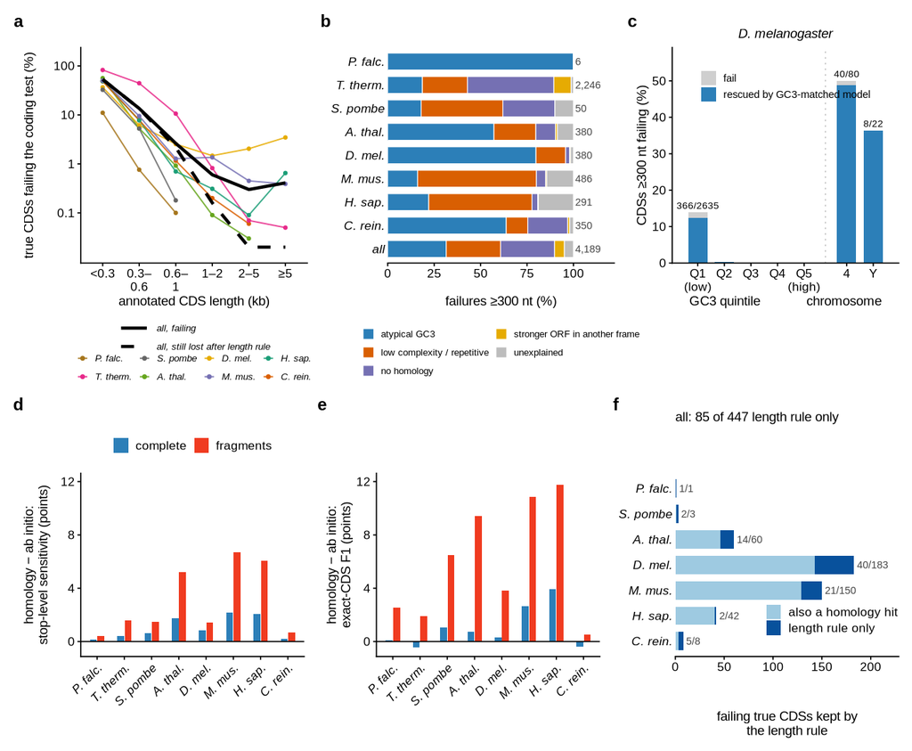

```r
ital_y <- theme(axis.text.y = element_text(face = "italic"))
ital_x <- theme(axis.text.x = element_text(face = "italic", angle = 45, hjust = 1))
pA <- ggplot() +
  geom_line(data = pa_org, aes(bin, fail_coding_pct, colour = org, group = org), linewidth = 0.35, alpha = 0.85) +
  geom_point(data = pa_org, aes(bin, fail_coding_pct, colour = org), size = 0.7) +
  geom_line(data = pa_all, aes(bin, pct, linetype = series, group = series), linewidth = 0.8) +
  scale_colour_manual(values = ORG_COLOR, labels = SHORT, name = NULL) +
  scale_linetype_manual(values = c("solid", "dashed"), name = NULL) +
  scale_y_log10(breaks = c(0.1, 1, 10, 100), labels = c("0.1", "1", "10", "100"), limits = c(0.015, 150)) +
  labs(x = "annotated CDS length (kb)", y = "true CDSs failing the coding test (%)") +
  guides(colour = guide_legend(ncol = 4, order = 2, override.aes = list(size = 0.8)),
         linetype = guide_legend(ncol = 1, order = 1, keywidth = unit(6, "mm"))) +
  theme(legend.position = "bottom", legend.box = "vertical", legend.text = element_text(size = 5, face = "italic"),
        legend.key.size = unit(2.2, "mm"), legend.spacing.y = unit(0, "mm"), legend.margin = margin(0, 0, 0, 0))
pB <- ggplot(pb, aes(fail_pct, org, fill = cause)) +
  geom_col(width = 0.72, colour = "white", linewidth = 0.2, position = position_stack(reverse = TRUE)) +
  geom_text(data = pb_n, aes(x = 101, y = org, label = num(n_fail)), inherit.aes = FALSE, hjust = 0,
            size = 1.9, colour = "#444444") +
  scale_fill_manual(values = ATTR_COL, labels = attr_lab, name = NULL) +
  scale_x_continuous(limits = c(0, 122), breaks = seq(0, 100, 25), expand = c(0, 0)) +
  labs(x = "failures ≥300 nt (%)", y = NULL) +
  guides(fill = guide_legend(ncol = 2)) + ital_y +
  theme(legend.position = "bottom", axis.line.y = element_blank(), axis.ticks.y = element_blank(),
        legend.text = element_text(size = 5), legend.key.size = unit(2.2, "mm"))
pC <- ggplot(pc, aes(x)) +
  geom_col(aes(y = fail_pct, fill = "fail"), width = 0.72) +
  geom_col(aes(y = rescued_pct, fill = "rescued by GC3-matched model"), width = 0.72) +
  geom_text(aes(y = fail_pct + 1, label = label), vjust = 0, size = 1.8, na.rm = TRUE) +
  geom_vline(xintercept = 4.8, colour = "#bbbbbb", linewidth = 0.3, linetype = "dotted") +
  scale_fill_manual(values = c(fail = "#cfcfcf", `rescued by GC3-matched model` = COMPLETE_C), name = NULL) +
  scale_x_continuous(breaks = pc$x, labels = pc$lab, expand = expansion(add = 0.6)) +
  scale_y_continuous(limits = c(0, max(58, max(pc$fail_pct) + 6)), expand = expansion(mult = c(0, 0.02))) +
  labs(x = "GC3 quintile             chromosome", y = "CDSs ≥300 nt failing (%)", title = "D. melanogaster") +
  theme(plot.title = element_text(face = "italic", hjust = 0.5), legend.position = "inside",
        legend.position.inside = c(0.5, 0.82), legend.text = element_text(size = 5.5))
hom_panel <- function(col, ylab) {
  ggplot(pde, aes(org, .data[[col]], fill = variant)) +
    geom_col(position = position_dodge(width = 0.55), width = 0.5) +
    geom_hline(yintercept = 0, linewidth = 0.3) +
    scale_fill_manual(values = c(complete = COMPLETE_C, fragments = FRAG_C), name = NULL) +
    coord_cartesian(ylim = c(-0.5, max(10, ceiling(max(pde$sens, pde$f1x))))) + labs(x = NULL, y = ylab) + ital_x
}
pD <- hom_panel("sens", "homology − ab initio:\nstop-level sensitivity (points)") + theme(legend.position = "top")
pE <- hom_panel("f1x", "homology − ab initio:\nexact-CDS F1 (points)") + theme(legend.position = "none")
lvh_all_lab <- sprintf("all: %d of %d length rule only", lvh_all$length_only, lvh_all$rescued_by_length)
pF <- pf %>% select(org, `also a homology hit` = also_homology_hit, `length rule only` = length_only) %>%
  pivot_longer(-org, names_to = "kind", values_to = "n") %>%
  ggplot(aes(n, org, fill = kind)) +
  geom_col(width = 0.72, position = position_stack(reverse = TRUE)) +
  geom_text(data = pf, aes(x = rescued_by_length + 3, y = org, label = paste0(length_only, "/", rescued_by_length)),
            inherit.aes = FALSE, hjust = 0, size = 1.9, colour = "#444444") +
  scale_fill_manual(values = c(`also a homology hit` = "#9ecae1", `length rule only` = TD_C), name = NULL) +
  scale_x_continuous(limits = c(0, max(pf$rescued_by_length) * 1.25), expand = c(0, 0)) +
  labs(x = "failing true CDSs kept by\nthe length rule", y = NULL, title = lvh_all_lab) + ital_y +
  theme(legend.position = "inside", legend.position.inside = c(0.7, 0.2), axis.line.y = element_blank(), axis.ticks.y = element_blank())
fig5 <- (pA | pB | pC) / (pD | pE | pF) + plot_layout(heights = c(1, 0.85)) +
  plot_annotation(tag_levels = "a")
save_fig(fig5, "fig5_failures", width = FULL_W, height = 150 * MM)
fig5
```

Panel data:

**a: failure rate by CDS length (%), per organism and all**

```r
kable(by_len %>% select(org, cds_len_bin, n, fail_coding, fail_coding_pct, still_lost, still_lost_pct))
```

| org | cds_len_bin | n | fail_coding | fail_coding_pct | still_lost | still_lost_pct |
| --- | --- | --- | --- | --- | --- | --- |
| athal | 0-299 | 1435 | 807 | 56.24 | 807 | 56.24 |
| athal | 300-599 | 4603 | 244 | 5.30 | 242 | 5.26 |
| athal | 600-999 | 6226 | 57 | 0.92 | 10 | 0.16 |
| athal | 1000-1999 | 10660 | 10 | 0.09 | 0 | 0.00 |
| athal | 2000-4999 | 3677 | 1 | 0.03 | 0 | 0.00 |
| athal | >=5000 | 171 | 0 | 0.00 | 0 | 0.00 |
| creinhardtii | 0-299 | 1182 | 572 | 48.39 | 572 | 48.39 |
| creinhardtii | 300-599 | 2134 | 167 | 7.83 | 167 | 7.83 |
| creinhardtii | 600-999 | 2580 | 30 | 1.16 | 30 | 1.16 |
| creinhardtii | 1000-1999 | 5112 | 10 | 0.20 | 5 | 0.10 |
| creinhardtii | 2000-4999 | 4948 | 3 | 0.06 | 0 | 0.00 |
| creinhardtii | >=5000 | 1665 | 0 | 0.00 | 0 | 0.00 |
| dmel | 0-299 | 708 | 259 | 36.58 | 259 | 36.58 |
| dmel | 300-599 | 2294 | 141 | 6.15 | 141 | 6.15 |
| dmel | 600-999 | 2768 | 70 | 2.53 | 30 | 1.08 |
| dmel | 1000-1999 | 4776 | 70 | 1.47 | 0 | 0.00 |
| dmel | 2000-4999 | 2746 | 56 | 2.04 | 0 | 0.00 |
| dmel | >=5000 | 492 | 17 | 3.46 | 0 | 0.00 |
| human | 0-299 | 552 | 270 | 48.91 | 270 | 48.91 |
| human | 300-599 | 2269 | 176 | 7.76 | 176 | 7.76 |
| human | 600-999 | 4003 | 28 | 0.70 | 17 | 0.42 |
| human | 1000-1999 | 7186 | 22 | 0.31 | 0 | 0.00 |
| human | 2000-4999 | 4368 | 4 | 0.09 | 0 | 0.00 |
| human | >=5000 | 766 | 5 | 0.65 | 0 | 0.00 |
| mouse | 0-299 | 537 | 270 | 50.28 | 270 | 50.28 |
| mouse | 300-599 | 2566 | 243 | 9.47 | 242 | 9.43 |
| mouse | 600-999 | 5568 | 71 | 1.28 | 46 | 0.83 |
| mouse | 1000-1999 | 7449 | 101 | 1.36 | 0 | 0.00 |
| mouse | 2000-4999 | 4474 | 20 | 0.45 | 0 | 0.00 |
| mouse | >=5000 | 767 | 3 | 0.39 | 0 | 0.00 |
| pfalciparum | 0-299 | 163 | 18 | 11.04 | 18 | 11.04 |
| pfalciparum | 300-599 | 659 | 5 | 0.76 | 5 | 0.76 |
| pfalciparum | 600-999 | 1013 | 1 | 0.10 | 0 | 0.00 |
| pfalciparum | 1000-1999 | 1524 | 0 | 0.00 | 0 | 0.00 |
| pfalciparum | 2000-4999 | 1362 | 0 | 0.00 | 0 | 0.00 |
| pfalciparum | >=5000 | 556 | 0 | 0.00 | 0 | 0.00 |
| spombe | 0-299 | 215 | 70 | 32.56 | 70 | 32.56 |
| spombe | 300-599 | 818 | 43 | 5.26 | 42 | 5.13 |
| spombe | 600-999 | 1137 | 2 | 0.18 | 0 | 0.00 |
| spombe | 1000-1999 | 1944 | 0 | 0.00 | 0 | 0.00 |
| spombe | 2000-4999 | 898 | 0 | 0.00 | 0 | 0.00 |
| spombe | >=5000 | 69 | 0 | 0.00 | 0 | 0.00 |
| tthermophila | 0-299 | 921 | 760 | 82.52 | 760 | 82.52 |
| tthermophila | 300-599 | 3432 | 1521 | 44.32 | 1521 | 44.32 |
| tthermophila | 600-999 | 4388 | 465 | 10.60 | 465 | 10.60 |
| tthermophila | 1000-1999 | 8524 | 70 | 0.82 | 70 | 0.82 |
| tthermophila | 2000-4999 | 7263 | 5 | 0.07 | 5 | 0.07 |
| tthermophila | >=5000 | 1861 | 1 | 0.05 | 1 | 0.05 |
| ALL | 0-299 | 5713 | 3026 | 52.97 | 3026 | 52.97 |
| ALL | 300-599 | 18775 | 2540 | 13.53 | 2536 | 13.51 |
| ALL | 600-999 | 27683 | 724 | 2.62 | 598 | 2.16 |
| ALL | 1000-1999 | 47175 | 283 | 0.60 | 75 | 0.16 |
| ALL | 2000-4999 | 29736 | 89 | 0.30 | 5 | 0.02 |
| ALL | >=5000 | 6347 | 26 | 0.41 | 1 | 0.02 |

**b: exclusive attribution of failures ≥300 nt (%)**

```r
kable(attr %>% select(org, n_fail, cause, fail_pct) %>% pivot_wider(names_from = cause, values_from = fail_pct))
```

| org | n_fail | low_complexity_or_repetitive | atypical_gc3_composition | stronger_out_of_frame_orf | no_homology_orphan | unexplained |
| --- | --- | --- | --- | --- | --- | --- |
| athal | 380 | 22.63 | 57.11 | 1.05 | 10.53 | 8.68 |
| creinhardtii | 350 | 11.71 | 63.71 | 1.14 | 21.43 | 2.00 |
| dmel | 380 | 16.05 | 79.74 | 0.53 | 2.11 | 1.58 |
| human | 291 | 55.67 | 21.99 | 0.34 | 3.09 | 18.90 |
| mouse | 486 | 63.99 | 16.05 | 0.62 | 4.94 | 14.40 |
| pfalciparum | 6 | 0.00 | 100.00 | 0.00 | 0.00 | 0.00 |
| spombe | 50 | 44.00 | 18.00 | 0.00 | 28.00 | 10.00 |
| tthermophila | 2246 | 24.35 | 18.57 | 9.35 | 46.48 | 1.25 |
| ALL | 4189 | 29.36 | 31.44 | 5.35 | 28.98 | 4.87 |

```r
kable(dmel_c, caption = "c: D. melanogaster CDSs >= 300 nt by GC3 quintile and chromosome.")
```

c: D. melanogaster CDSs >= 300 nt by GC3 quintile and chromosome.

| group | lo | hi | n | fail_score | rescued_gc3_model |
| --- | --- | --- | --- | --- | --- |
| gc3_q1 | 0.2113 | 0.5611 | 2635 | 366 | 328 |
| gc3_q2 | 0.5613 | 0.6280 | 2634 | 9 | 6 |
| gc3_q3 | 0.6280 | 0.6761 | 2635 | 3 | 1 |
| gc3_q4 | 0.6761 | 0.7288 | 2634 | 1 | 0 |
| gc3_q5 | 0.7289 | 0.9564 | 2634 | 1 | 0 |
| chr4 | NA | NA | 80 | 40 | 39 |
| chrY | NA | NA | 22 | 8 | 8 |
| other_chr | NA | NA | 13070 | 332 | 288 |

```r
kable(pde %>% select(org, variant, d_sensitivity_stop, d_f1_exact), caption = "d, e: homology minus ab initio (fractions; plotted x 100).")
```

d, e: homology minus ab initio (fractions; plotted x 100).

| org | variant | d_sensitivity_stop | d_f1_exact |
| --- | --- | --- | --- |
| A. thal. | complete | 0.0176 | 0.0074 |
| C. rein. | complete | 0.0018 | -0.0036 |
| D. mel. | complete | 0.0085 | 0.0031 |
| H. sap. | complete | 0.0205 | 0.0392 |
| M. mus. | complete | 0.0219 | 0.0266 |
| P. falc. | complete | 0.0017 | 0.0012 |
| S. pombe | complete | 0.0063 | 0.0104 |
| T. therm. | complete | 0.0040 | -0.0044 |
| A. thal. | fragments | 0.0521 | 0.0944 |
| C. rein. | fragments | 0.0068 | 0.0052 |
| D. mel. | fragments | 0.0140 | 0.0384 |
| H. sap. | fragments | 0.0606 | 0.1177 |
| M. mus. | fragments | 0.0669 | 0.1087 |
| P. falc. | fragments | 0.0042 | 0.0255 |
| S. pombe | fragments | 0.0149 | 0.0649 |
| T. therm. | fragments | 0.0156 | 0.0191 |

```r
kable(lvh, caption = "f: failing true CDSs kept by the length rule.")
```

f: failing true CDSs kept by the length rule.

| org | fail_coding | rescued_by_length | with_homology_data | also_homology_hit | length_only |
| --- | --- | --- | --- | --- | --- |
| athal | 1119 | 60 | 60 | 46 | 14 |
| creinhardtii | 782 | 8 | 8 | 3 | 5 |
| dmel | 613 | 183 | 183 | 143 | 40 |
| human | 505 | 42 | 42 | 40 | 2 |
| mouse | 708 | 150 | 150 | 129 | 21 |
| pfalciparum | 24 | 1 | 1 | 0 | 1 |
| spombe | 115 | 3 | 3 | 1 | 2 |
| tthermophila | 2822 | 0 | 0 | 0 | 0 |
| ALL | 6688 | 447 | 447 | 362 | 85 |

## Development rule vs release rule

```r
cmp_org <- by_org %>% select(org, n_matched, fail_coding_pct, fail_ge300_pct_of_ge300, rescued_by_long_rule,
                             fail_lost_pct_of_matched) %>%
  left_join(dev_by_org %>% select(org, dev_n_matched = n_matched, dev_fail_coding_pct = fail_coding_pct,
                                  dev_fail_ge300_pct = fail_ge300_pct_of_ge300,
                                  dev_rescued_by_long_rule = rescued_by_long_rule,
                                  dev_fail_lost_pct = fail_lost_pct_of_matched), by = "org")
kable(cmp_org)
```

| org | n_matched | fail_coding_pct | fail_ge300_pct_of_ge300 | rescued_by_long_rule | fail_lost_pct_of_matched | dev_n_matched | dev_fail_coding_pct | dev_fail_ge300_pct | dev_rescued_by_long_rule | dev_fail_lost_pct |
| --- | --- | --- | --- | --- | --- | --- | --- | --- | --- | --- |
| athal | 26772 | 4.18 | 1.49 | 60 | 3.96 | 26772 | 4.71 | 0.92 | 60 | 4.48 |
| creinhardtii | 17621 | 4.44 | 2.09 | 8 | 4.39 | 17621 | 5.82 | 2.09 | 8 | 5.77 |
| dmel | 13784 | 4.45 | 2.88 | 183 | 3.12 | 13784 | 5.78 | 2.80 | 183 | 4.45 |
| human | 19144 | 2.64 | 1.55 | 42 | 2.42 | 19144 | 2.12 | 0.86 | 42 | 1.90 |
| mouse | 21361 | 3.31 | 2.32 | 150 | 2.61 | 21361 | 2.98 | 1.71 | 150 | 2.28 |
| pfalciparum | 5277 | 0.45 | 0.12 | 1 | 0.44 | 5277 | 2.94 | 0.12 | 1 | 2.92 |
| spombe | 5081 | 2.26 | 1.02 | 3 | 2.20 | 5081 | 3.25 | 0.92 | 3 | 3.19 |
| tthermophila | 26389 | 10.69 | 8.73 | 0 | 10.69 | 26389 | 8.27 | 6.18 | 0 | 8.27 |
| ALL | 135429 | 4.94 | 3.20 | 447 | 4.61 | 135429 | 4.89 | 2.38 | 447 | 4.56 |

## Checks against the manuscript

Values quoted in `results_coding_failures.tex` (line numbers in the labels) against the release analysis.

```r
ok <- function(...) invisible(check_text(...))
ok("L14 matched CDSs", ALL$n_matched, 135429)
ok("L15 % failing", round(fail_pct, 1), 4.9, 0.05)
ok("L19 % failing <300 nt", round(lp[["0-299"]]), 53, 0.5)
ok("L20 % failing 300-599", round(lp[["300-599"]], 1), 13.5, 0.05)
ok("L21 % failing 600-999", round(lp[["600-999"]], 1), 2.6, 0.05)
ok("L22 % failing 1-2 kb", round(lp[["1000-1999"]], 1), 0.6, 0.05)
ok("L23 % failing 2-5 kb (0.3-0.4)", round(lp[["2000-4999"]], 1), 0.3, 0.05)
ok("L23 % failing >=5 kb (0.3-0.4)", round(lp[[">=5000"]], 1), 0.4, 0.05)
ok("L25 failing CDSs >= 1 kb", n_ge1kb, 398)
ok("L25-28 named genes failing (of 8)", nrow(named_tab), 8)
ok("L31 T. thermophila failing >=1 kb lost", tt_lost_1kb, 76)
ok("L32 failing CDSs kept by length rule", lvh_all$rescued_by_length, 447)
ok("L33 length rule only", lvh_all$length_only, 85)
ok("L33 length rule only (%)", round(lo_pct), 19, 0.5)
ok("L38 % not predicted", round(lost_pct, 1), 4.6, 0.05)
ok("L39 length-only predictions, min %", round(min(lro_b$length_rule_only_pct), 1), 0, 0.05)
ok("L39 length-only predictions, max %", round(max(lro_b$length_rule_only_pct), 1), 1.4, 0.05)
ok("L40 length-only on complete, false", lo_false, 5)
ok("L40 length-only on complete, total", lo_total, 409)
ok("L41 human lncRNA input, length-only true", h_lnc$lo_is_truth_cds, 49)
ok("L41 human lncRNA input, length-only on lncRNAs", h_lnc$lo_on_negative_transcript, 159)
ok("L44 attribution: atypical GC3 %", round(attr_all[["atypical_gc3_composition"]]), 31, 0.5)
ok("L45 attribution: low complexity %", round(attr_all[["low_complexity_or_repetitive"]]), 29, 0.5)
ok("L45 attribution: no homology + other frame %",
   round(attr_all[["no_homology_orphan"]] + attr_all[["stronger_out_of_frame_orf"]]), 34, 0.5)
ok("L45 attribution: no homology %", round(attr_all[["no_homology_orphan"]]), 29, 0.5)
ok("L45 attribution: stronger ORF other frame %", round(attr_all[["stronger_out_of_frame_orf"]], 1), 5.3, 0.05)
ok("L46 attribution: unexplained %", round(attr_all[["unexplained"]], 1), 4.9, 0.05)
ok("L51 D. mel lowest GC3 quintile failing %", round(dq$fail_score_pct[1], 1), 13.9, 0.05)
ok("L52 D. mel other quintiles, max %", round(max(dq$fail_score_pct[-1]), 1), 0.3, 0.05)
ok("L52 D. mel chr 4 failing", chr4$fail_score, 40)
ok("L52 D. mel chr 4 n", chr4$n, 80)
ok("L52 D. mel chr Y failing", chrY$fail_score, 8)
ok("L53 D. mel chr Y n", chrY$n, 22)
ok("L56 T. therm ribosomal proteins failing", tt_rp$rp_fail, 29)
ok("L56 T. therm ribosomal proteins n", tt_rp$n_rp, 60)
ok("L58 GC3 model rescue, all %", round(o_all$gc3match500_rescues_td_scorefail_pct), 27, 0.5)
ok("L59 GC3 model rescue, D. mel %", round(o_dmel$gc3match500_rescues_td_scorefail_pct), 63, 0.5)
ok("L59 GC3 model rescue, chr 4", chr4$rescued_gc3_model, 39)
ok("L61 other models fail %, min", round(min(other_models), 2), 2.78, 0.005)
ok("L61 other models fail %, max", round(max(other_models), 2), 3.23, 0.005)
ok("L61 TD model fail % (>=300 nt)", round(o_all$td_fail_ge300_pct, 2), 3.2, 0.005)
ok("L61 training ORFs true CDSs, min %", round(100 * min(purity), 1), 99.8, 0.05)
ok("L62 training ORFs true CDSs, max %", round(100 * max(purity), 1), 100, 0.05)
ok("L69 human+mouse failures low complexity %", round(lowc_fail), 61, 0.5)
ok("L70 human+mouse controls low complexity %", round(lowc_ctrl), 14, 0.5)
ok("L71 human KRTAP failing", if (nrow(krtap)) krtap$n_fail else 0, 55)
ok("L71 human KRTAP n", if (nrow(krtap)) krtap$n else NA, 72)
ok("L74 human failing Cys %", round(100 * cys$fail_mean), 10, 0.5)
ok("L74 human control Cys %", round(100 * cys$ctrl_mean, 1), 2.4, 0.05)
ok("L75 low-complexity fraction fold", round(seg$fail_mean / seg$ctrl_mean), 3, 0.5)
ok("L79 T. therm failures without homology %", round(tt_orph$fail_pct), 95, 0.5)
ok("L80 T. therm controls without homology %", round(tt_orph$ctrl_pct), 52, 0.5)
ok("L80 T. therm stronger ORF other frame %", round(tt_alt$fail_pct), 19, 0.5)
ok("L81 human failing without Swiss-Prot hit %", round(h_sp$fail_score_pct[h_sp$has_sprot == 0], 1), 20.5, 0.05)
ok("L82 human failing with Swiss-Prot hit %", round(h_sp$fail_score_pct[h_sp$has_sprot == 1], 1), 0.9, 0.05)
ok("L89 dropping S1>0: true CDSs changed, min %", round(min(alt_r$pos_gain_pct), 2), -0.66, 0.005)
ok("L89 dropping S1>0: true CDSs changed, max %", round(max(alt_r$pos_gain_pct), 2), 0.65, 0.005)
ok("L90 dropping S1>0: random fold, min", round(min(alt_r$neg_fold), 1), 1.4, 0.05)
ok("L90 dropping S1>0: random fold, max", round(max(alt_r$neg_fold), 1), 7.9, 0.05)
ok("L90 dropping S1>0: random fold, median", round(median(alt_r$neg_fold), 1), 2.5, 0.05)
# homology paragraph (released homology mode, a5b24c3 pytd_v7h_homology; values updated 2026-10-28 from
# the 3a793ff runs: stop-level values unchanged, exact-F1 values new; manuscript text to follow)
other5 <- frag_s[setdiff(names(frag_s), c("human", "mouse", "athal"))]
ok("homology inputs", nrow(hom), 84)
ok("complete inputs", nrow(hc), 48)
ok("complete: sensitivity change min", round(100 * min(hc$d_sensitivity_stop), 1), -0.3, 0.05)
ok("complete: sensitivity change max", round(100 * max(hc$d_sensitivity_stop), 1), 3.7, 0.05)
ok("complete: exact F1 min", round(100 * min(hc$d_f1_exact), 1), -0.4, 0.05)  # -0.44 (3a793ff -0.35)
ok("complete: exact F1 max", round(100 * max(hc$d_f1_exact), 1), 4.8, 0.05)  # 3a793ff 2.1
ok("fragment inputs", nrow(hf), 32)
ok("fragments: sensitivity min", round(100 * min(hf$d_sensitivity_stop), 1), 0.4, 0.05)
ok("fragments: sensitivity max", round(100 * max(hf$d_sensitivity_stop), 1), 9.2, 0.05)
ok("fragments: exact F1 min", round(100 * min(hf$d_f1_exact), 1), 0.5, 0.05)  # 3a793ff 0.1
ok("fragments: exact F1 max", round(100 * max(hf$d_f1_exact), 1), 12.9, 0.05)  # 3a793ff 4.65
ok("stranded fragments F1, min of human/mouse/athal", round(min(frag_s[c("human", "mouse", "athal")]), 1), 9.4, 0.05)  # 3a793ff 2.3
ok("stranded fragments F1, max of human/mouse/athal", round(max(frag_s[c("human", "mouse", "athal")]), 1), 11.8, 0.05)  # 3a793ff 3.1
ok("stranded fragments F1, other five min", round(min(other5), 1), 0.5, 0.05)  # 3a793ff 0.1
ok("stranded fragments F1, other five max", round(max(other5), 1), 6.5, 0.05)  # 3a793ff 0.65
ok("precision change min", round(100 * min(hneg$d_precision_stop), 1), -0.5, 0.05)
ok("precision change max", round(100 * max(hneg$d_precision_stop), 1), 1.3, 0.05)
ok("random calls added, 7 orgs, min", min(rand_other$d_neg), 0)
ok("random calls added, 7 orgs, max", max(rand_other$d_neg), 2)
ok("random calls added, T. therm, min", min(rand_tt$d_neg), 12)
ok("random calls added, T. therm, max", max(rand_tt$d_neg), 39)
ok("human lncRNAs predicted, ab initio", lncv("human", "complete.wLnc", neg_pred_abinitio), 1639)
ok("human lncRNAs predicted, homology", lncv("human", "complete.wLnc", neg_pred_homology), 3268)
ok("mouse lncRNAs predicted, ab initio", lncv("mouse", "complete.wLnc", neg_pred_abinitio), 1640)
ok("mouse lncRNAs predicted, homology", lncv("mouse", "complete.wLnc", neg_pred_homology), 2452)
ok("complete+lnc exact F1, human", round(100 * lncv("human", "complete.wLnc", d_f1_exact), 1), 0.6, 0.05)  # 3a793ff -2.1
ok("complete+lnc exact F1, mouse", round(100 * lncv("mouse", "complete.wLnc", d_f1_exact), 1), 1.4, 0.05)  # 3a793ff -0.1
ok("fragments+lnc exact F1, human", round(100 * lncv("human", "fragments.wLnc", d_f1_exact), 1), 8.8, 0.05)  # 3a793ff 0.2
ok("fragments+lnc exact F1, mouse", round(100 * lncv("mouse", "fragments.wLnc", d_f1_exact), 1), 9.6, 0.05)  # 3a793ff 2.3
check_report()
```

| claim | computed | manuscript | ok |
| --- | --- | --- | --- |
| L14 matched CDSs | 135429 | 135429 | TRUE |
| L15 % failing | 4.9 | 4.9 | TRUE |
| L19 % failing <300 nt | 53 | 53 | TRUE |
| L20 % failing 300-599 | 13.5 | 13.5 | TRUE |
| L21 % failing 600-999 | 2.6 | 2.6 | TRUE |
| L22 % failing 1-2 kb | 0.6 | 0.6 | TRUE |
| L23 % failing 2-5 kb (0.3-0.4) | 0.3 | 0.3 | TRUE |
| L23 % failing >=5 kb (0.3-0.4) | 0.4 | 0.4 | TRUE |
| L25 failing CDSs >= 1 kb | 398 | 398 | TRUE |
| L25-28 named genes failing (of 8) | 8 | 8 | TRUE |
| L31 T. thermophila failing >=1 kb lost | 76 | 76 | TRUE |
| L32 failing CDSs kept by length rule | 447 | 447 | TRUE |
| L33 length rule only | 85 | 85 | TRUE |
| L33 length rule only (%) | 19 | 19 | TRUE |
| L38 % not predicted | 4.6 | 4.6 | TRUE |
| L39 length-only predictions, min % | 0 | 0 | TRUE |
| L39 length-only predictions, max % | 1.4 | 1.4 | TRUE |
| L40 length-only on complete, false | 5 | 5 | TRUE |
| L40 length-only on complete, total | 409 | 409 | TRUE |
| L41 human lncRNA input, length-only true | 49 | 49 | TRUE |
| L41 human lncRNA input, length-only on lncRNAs | 159 | 159 | TRUE |
| L44 attribution: atypical GC3 % | 31 | 31 | TRUE |
| L45 attribution: low complexity % | 29 | 29 | TRUE |
| L45 attribution: no homology + other frame % | 34 | 34 | TRUE |
| L45 attribution: no homology % | 29 | 29 | TRUE |
| L45 attribution: stronger ORF other frame % | 5.3 | 5.3 | TRUE |
| L46 attribution: unexplained % | 4.9 | 4.9 | TRUE |
| L51 D. mel lowest GC3 quintile failing % | 13.9 | 13.9 | TRUE |
| L52 D. mel other quintiles, max % | 0.3 | 0.3 | TRUE |
| L52 D. mel chr 4 failing | 40 | 40 | TRUE |

[output cut: 59 more lines]